# Reproducible Research: Peer Assessment 1

I am going to need tidyverse so just loading that up here.

```r
library(tidyverse)
```

## Loading and preprocessing the data

The problem states

> The variables included in this dataset are:  
> steps: Number of steps taking in a 5-minute interval (missing values are coded as NA)  
> date: The date on which the measurement was taken in YYYY-MM-DD format  
> interval: Identifier for the 5-minute interval in which measurement was taken  
> The dataset is stored in a comma-separated-value (CSV) file and there are a total of 17,568 >observations in this dataset.

```r
activity = read_csv('activity/activity.csv', col_types = cols(
  steps = col_double(),
  date = col_date(),
  interval = col_integer()
))
head(activity)
```

```
## # A tibble: 6 x 3
##   steps date       interval
##   <dbl> <date>        <int>
## 1    NA 2012-10-01        0
## 2    NA 2012-10-01        5
## 3    NA 2012-10-01       10
## 4    NA 2012-10-01       15
## 5    NA 2012-10-01       20
## 6    NA 2012-10-01       25
```

```r
summary(activity)
```

```
##      steps             date               interval
##  Min.   :  0.00   Min.   :2012-10-01   Min.   :   0.0
##  1st Qu.:  0.00   1st Qu.:2012-10-16   1st Qu.: 588.8
##  Median :  0.00   Median :2012-10-31   Median :1177.5
##  Mean   : 37.38   Mean   :2012-10-31   Mean   :1177.5
##  3rd Qu.: 12.00   3rd Qu.:2012-11-15   3rd Qu.:1766.2
##  Max.   :806.00   Max.   :2012-11-30   Max.   :2355.0
##  NA's   :2304
```

Looks sort of right. The steps are 0 a lot. Perhaps people are sleeping?

## What is mean total number of steps taken per day?

```r
all_daily_mean_steps = summarize(group_by(activity, date), mean_steps=mean(steps))
all_daily_mean_steps
```

```
## # A tibble: 61 x 2
##    date       mean_steps
##    <date>          <dbl>
##  1 2012-10-01     NA
##  2 2012-10-02      0.438
##  3 2012-10-03     39.4
##  4 2012-10-04     42.1
##  5 2012-10-05     46.2
##  6 2012-10-06     53.5
##  7 2012-10-07     38.2
##  8 2012-10-08     NA
##  9 2012-10-09     44.5
## 10 2012-10-10     34.4
## # ... with 51 more rows
```

Those NAs are making me nervous, so let’s drop them:

```r
activity_lite = drop_na(activity)
daily_mean_steps = summarize(group_by(activity_lite, date), daily_mean_steps=mean(steps))
daily_mean_steps
```

```
## # A tibble: 53 x 2
##    date       daily_mean_steps
##    <date>                <dbl>
##  1 2012-10-02            0.438
##  2 2012-10-03           39.4
##  3 2012-10-04           42.1
##  4 2012-10-05           46.2
##  5 2012-10-06           53.5
##  6 2012-10-07           38.2
##  7 2012-10-09           44.5
##  8 2012-10-10           34.4
##  9 2012-10-11           35.8
## 10 2012-10-12           60.4
## # ... with 43 more rows
```

That looks better, so now I can just look at the histogram and mean

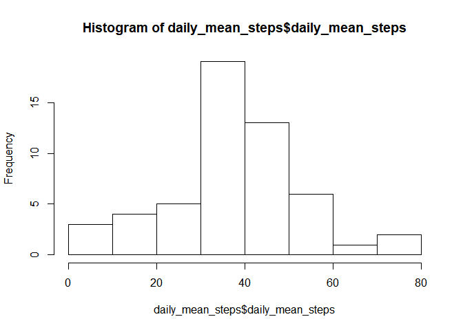

```r
hist(daily_mean_steps$daily_mean_steps)
```

```r
mean(daily_mean_steps$daily_mean_steps)
```

```
## [1] 37.3826
```

## What is the average daily activity pattern?

We already have this so let’s just look at it.

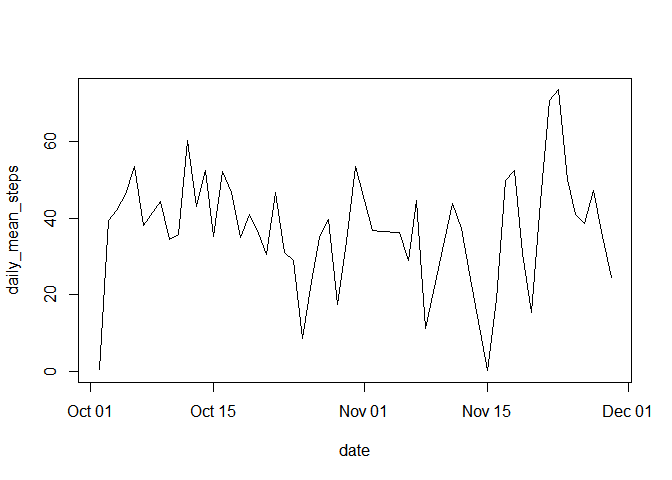

```r
plot(daily_mean_steps, type="l")
```

No, the question asked for steps over the time of day over all days.

```r
interval_mean_steps = summarize(group_by(activity_lite, interval), interval_mean_steps=mean(steps))
interval_mean_steps
```

```
## # A tibble: 288 x 2
##    interval interval_mean_steps
##       <int>               <dbl>
##  1        0              1.72
##  2        5              0.340
##  3       10              0.132
##  4       15              0.151
##  5       20              0.0755
##  6       25              2.09
##  7       30              0.528
##  8       35              0.868
##  9       40              0
## 10       45              1.47
## # ... with 278 more rows
```

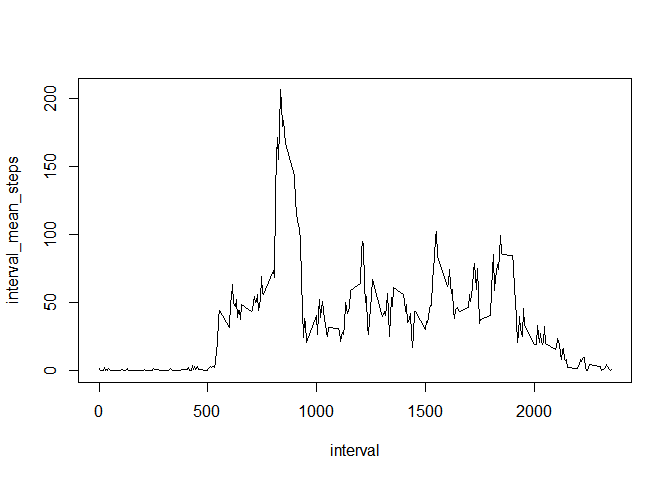

```r
plot(interval_mean_steps, type = 'l')
```

Let’s see if that is roughly right:

```r
max_interval = interval_mean_steps$interval[interval_mean_steps$interval_mean_steps == max(interval_mean_steps$interval_mean_steps)]
print(max_interval)
```

```
## [1] 835
```

```r
print(max_interval/60)
```

```
## [1] 13.91667
```

## Imputing missing values

We could replace the steps by the average for the day or the interval. I can imagine that the interval is more important (you sleep at midnight whether or not you took a hike earlier) Or we can just use the local information before and after to do a fill. The problem with the local information is that it can change pretty sharply, so if most of the NAs are at night, and it stopped collecting during a walk, we don’t want it to show the person walking all night.

```r
a = left_join(activity, interval_mean_steps, by = "interval")
a$steps[is.na(a$steps)] <- a$interval_mean_steps[is.na(a$steps)]
```

The original steps had a mean and median of:

```r
mean(activity_lite$steps)
```

```
## [1] 37.3826
```

```r
median(activity_lite$steps)
```

```
## [1] 0
```

And the modified one has a mean and median of:

```r
mean(a$steps)
```

```
## [1] 37.3826
```

```r
median(a$steps)
```

```
## [1] 0
```

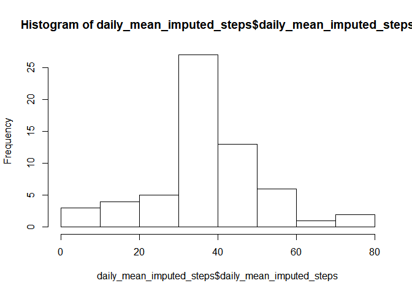

```r
daily_mean_imputed_steps = summarize(group_by(a, date), daily_mean_imputed_steps=mean(steps))
hist(daily_mean_imputed_steps$daily_mean_imputed_steps)
```

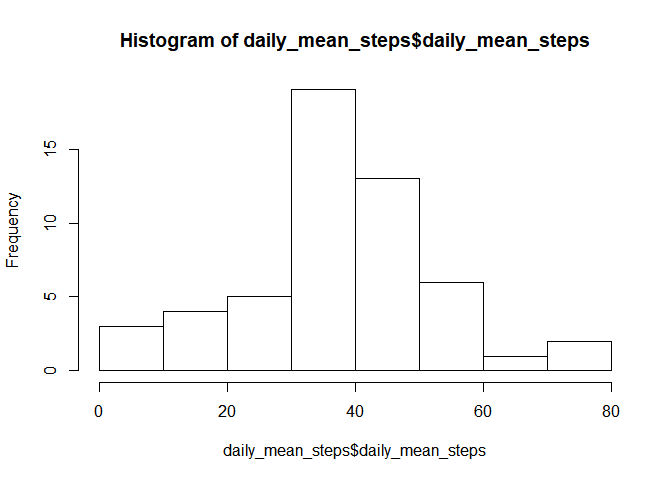

```r
hist(daily_mean_steps$daily_mean_steps)
```

## Are there differences in activity patterns between weekdays and weekends?

Create the weekday:

```r
activity_lite$weekday = weekdays(activity_lite$date)
activity_lite
```

```
## # A tibble: 15,264 x 4
##    steps date       interval weekday
##    <dbl> <date>        <int> <chr>
##  1     0 2012-10-02        0 Tuesday
##  2     0 2012-10-02        5 Tuesday
##  3     0 2012-10-02       10 Tuesday
##  4     0 2012-10-02       15 Tuesday
##  5     0 2012-10-02       20 Tuesday
##  6     0 2012-10-02       25 Tuesday
##  7     0 2012-10-02       30 Tuesday
##  8     0 2012-10-02       35 Tuesday
##  9     0 2012-10-02       40 Tuesday
## 10     0 2012-10-02       45 Tuesday
## # ... with 15,254 more rows
```

Create the weekend:

```r
activity_lite$weekend[grepl("Saturday|Sunday", activity_lite$weekday)]= ("Weekend")
activity_lite$weekend[!grepl("Saturday|Sunday", activity_lite$weekday)]=("Weekday")
activity_lite$weekend <- as.factor(activity_lite$weekend)
activity_lite
```

```
## # A tibble: 15,264 x 5
##    steps date       interval weekday weekend
##    <dbl> <date>        <int> <chr>   <fct>
##  1     0 2012-10-02        0 Tuesday Weekday
##  2     0 2012-10-02        5 Tuesday Weekday
##  3     0 2012-10-02       10 Tuesday Weekday
##  4     0 2012-10-02       15 Tuesday Weekday
##  5     0 2012-10-02       20 Tuesday Weekday
##  6     0 2012-10-02       25 Tuesday Weekday
##  7     0 2012-10-02       30 Tuesday Weekday
##  8     0 2012-10-02       35 Tuesday Weekday
##  9     0 2012-10-02       40 Tuesday Weekday
## 10     0 2012-10-02       45 Tuesday Weekday
## # ... with 15,254 more rows
```

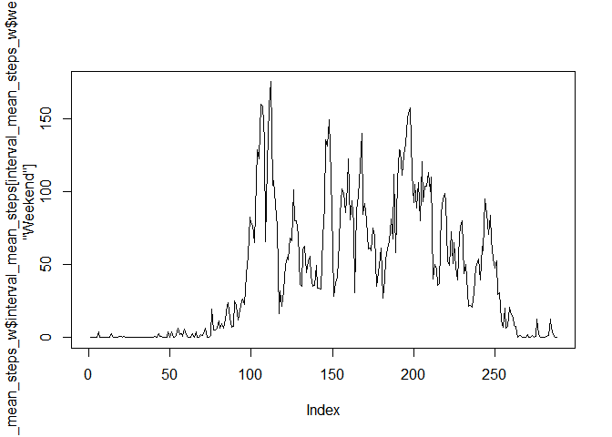

```r
interval_mean_steps_w = summarize(group_by(activity_lite, interval, weekend), interval_mean_steps=mean(steps))
plot(interval_mean_steps_w$interval_mean_steps[interval_mean_steps_w$weekend=="Weekend"], type="l")
```

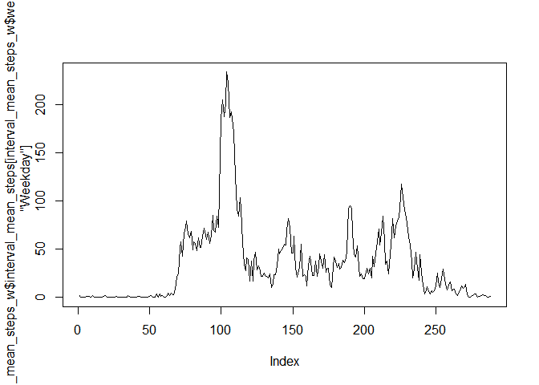

```r
plot(interval_mean_steps_w$interval_mean_steps[interval_mean_steps_w$weekend=="Weekday"], type="l")
```